# osm-cycling-change-framework

Can We Trust OpenStreetMap to Measure Cycling-Infrastructure Change?

A Reproducible Validation Framework Using Google Street View

Eugeni Vidal-Tortosa, Víctor Gonzàlez-Parra, Oriol Marquet

GEMOTT, Universitat Autònoma de Barcelona  
WSTLUR 2026 · Beijing

[figure not shown]

[figure not shown]

[figure not shown]

Project: 101117700 — ATRAPA — ERC-2023-STG

## Why does this matter?

INTRODUCTION

- Cities are rapidly expanding cycling infrastructure
- We need *longitudinal* data to understand its impacts
- OpenStreetMap (OSM) offers global, historical data
- But can we trust OSM to detect *change* over time?

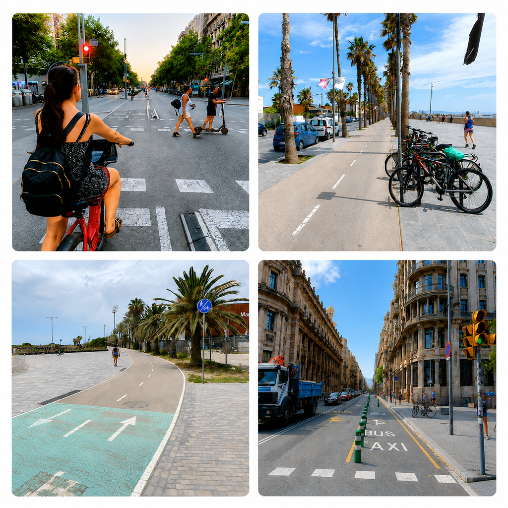

## Research aim

INTRODUCTION

Quantify the accuracy of OSM for detecting cycling-infrastructure change

## Study setting and data

DATA & METHODS

**Study setting**

- Barcelona, Spain
- 2015–2023

**Data sources**

- Historical OSM cycling-infrastructure snapshots
- Census-tract boundaries
- Historical Google Street View (GSV) imagery

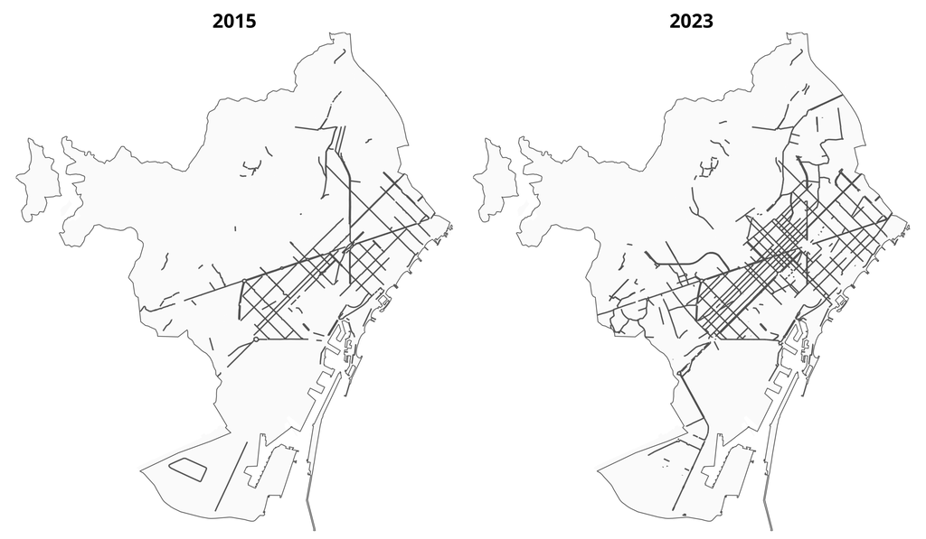

## Analytical workflow

DATA & METHODS

1. Detect OSM cycling-infrastructure change

↓

2. Stratify census-tracts

↓

3. Generate network validation points

↓

4. Inspect and code historical GSV imagery

↓

5. Calculate validation metrics

### 1. Detect OSM cycling-infrastructure changes

DATA & METHODS

- OSM differencing identified:
  - 127 km additions
  - 25 km removals
- Net network growth:
  - +80%
- 946 candidate change segments

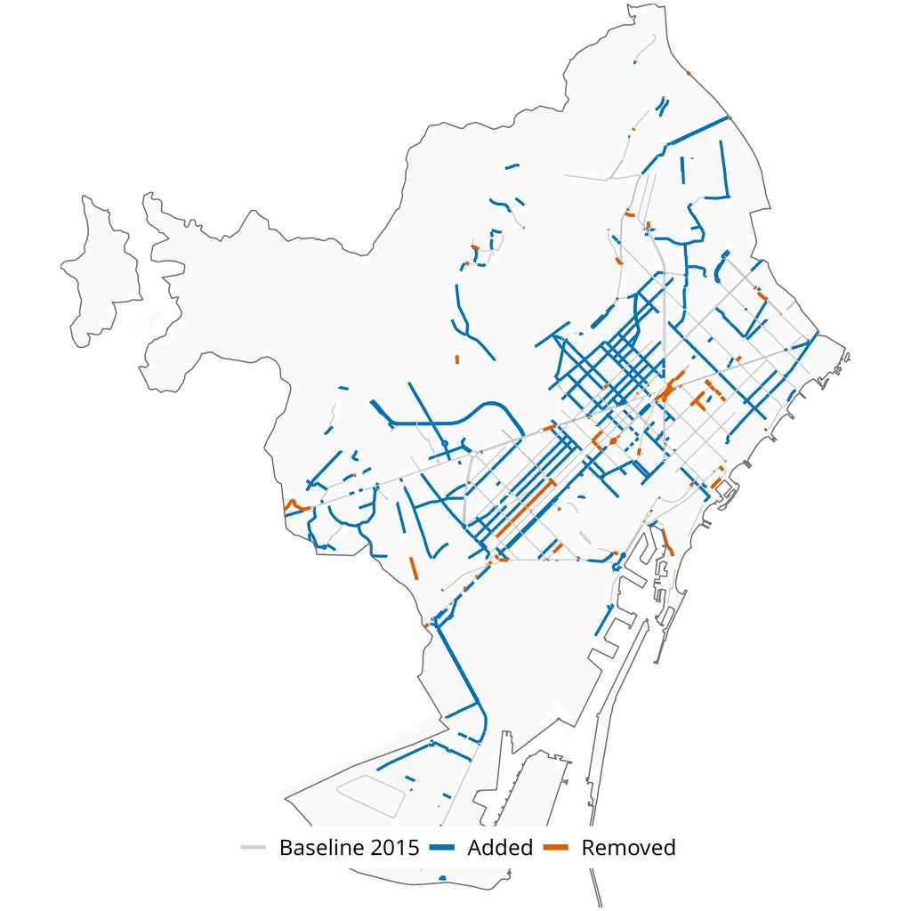

### 2. Stratify census-tracts

DATA & METHODS

- Barcelona stratified by:
  - population density
  - centrality
- 3 × 3 density–centrality strata
- 6 census tracts randomly sampled per stratum (54 total)

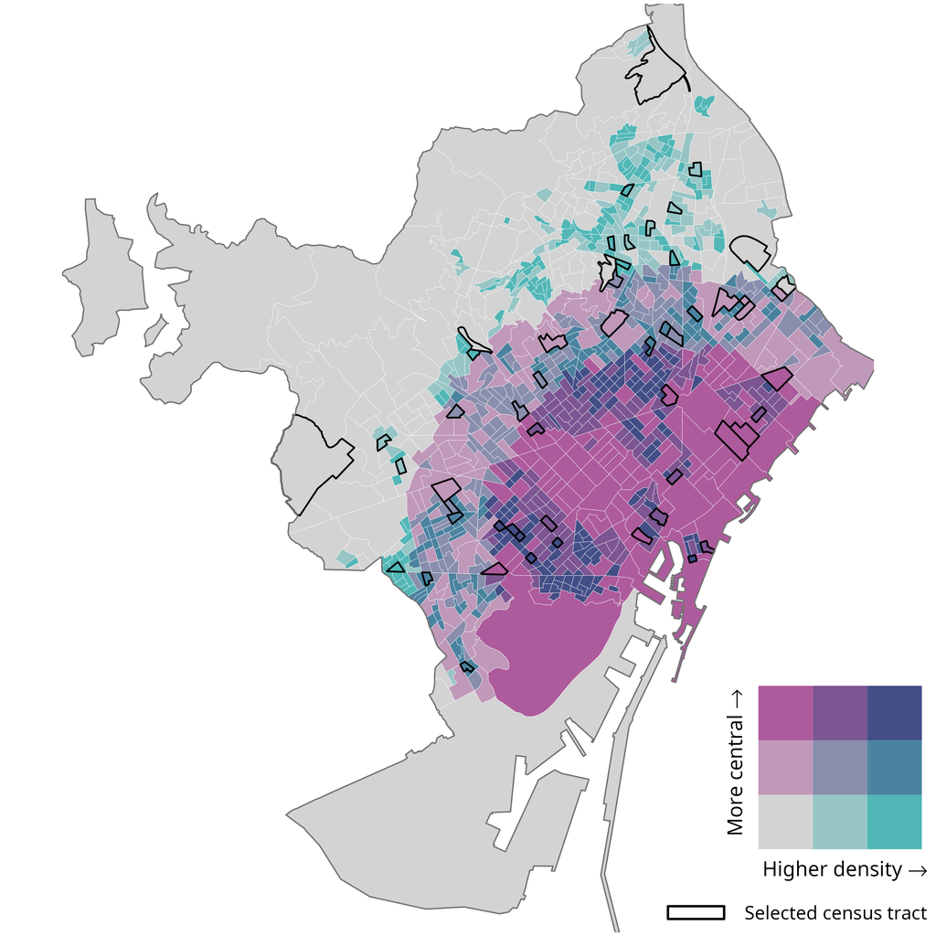

### 3. Generate network validation points

DATA & METHODS

- Validation points sampled within selected census tracts
- Up to:
  - 2 additions
  - 2 removals
  - 1 non-cycling control
- Points linked to historical GSV imagery

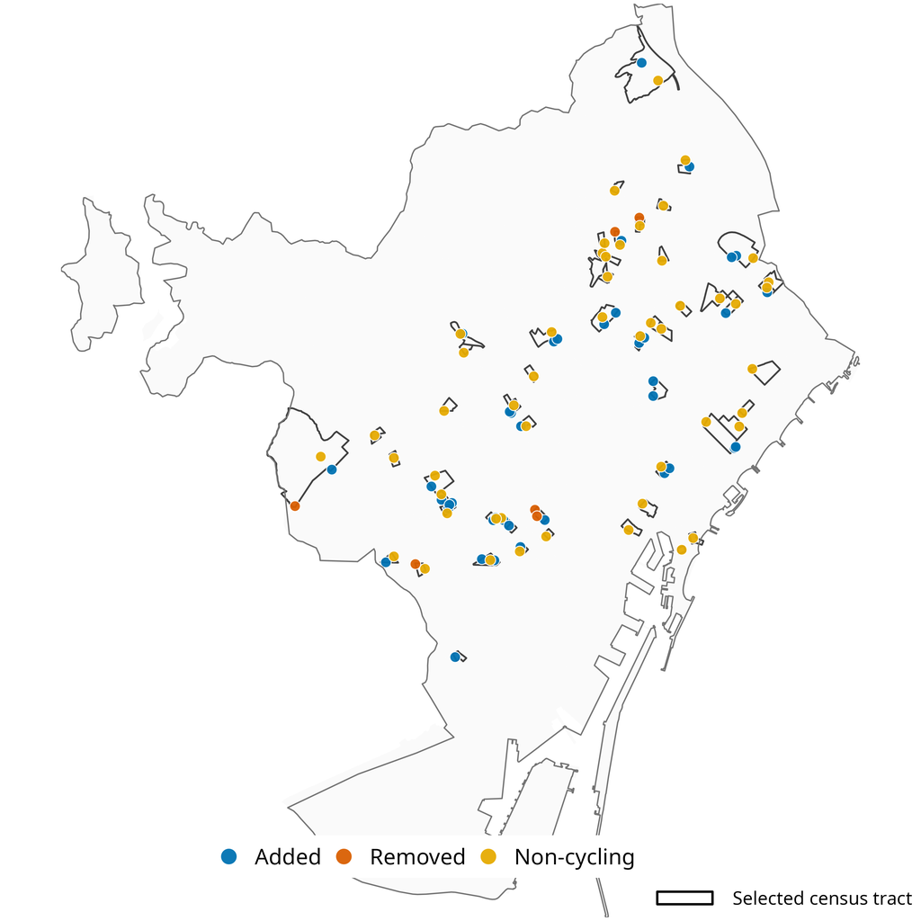

### 4. Inspect and code historical GSV imagery

DATA & METHODS

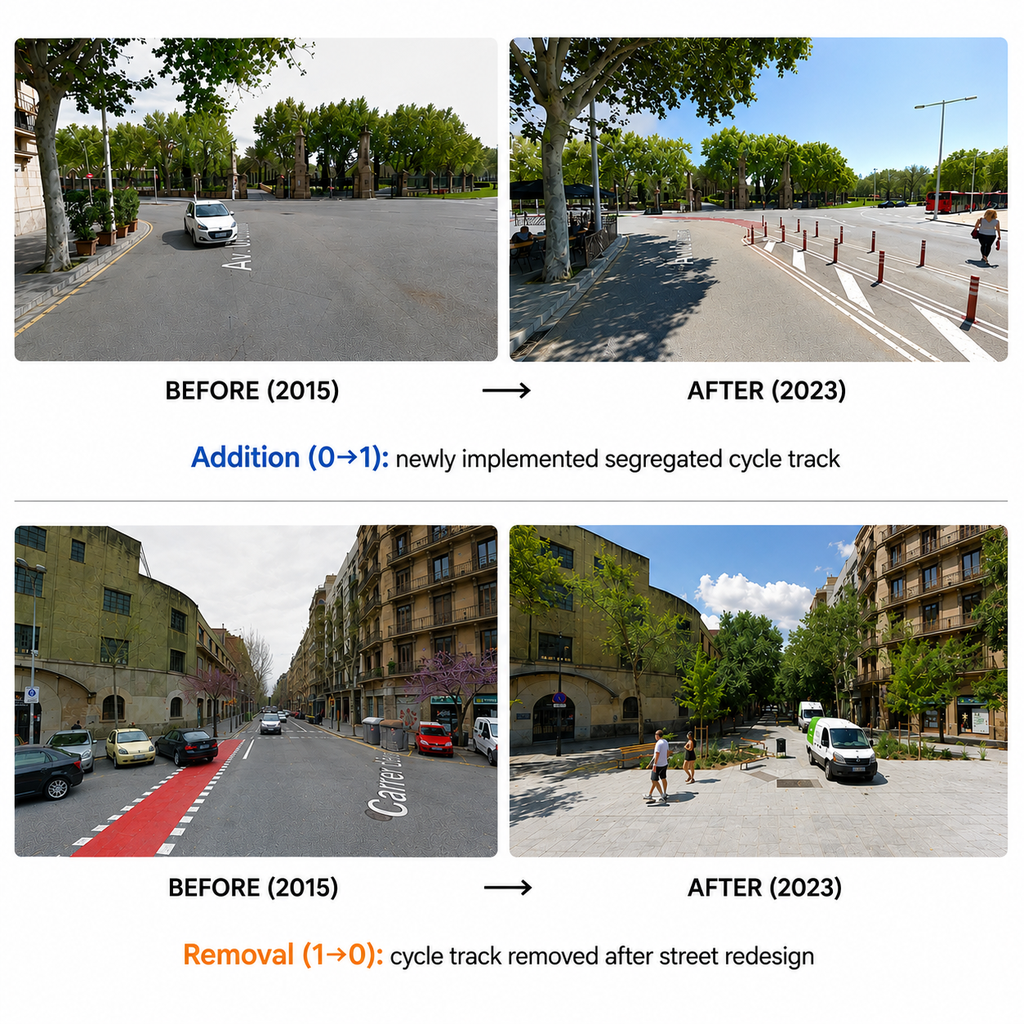

### 5. Calculate validation metrics

DATA & METHODS

$\mathrm{Precision} = \frac{TP}{TP + FP}$

What proportion of detected OSM changes are real?

$\mathrm{Recall} = \frac{TP}{TP + FN}$

What proportion of real changes are captured by OSM?

## Validation performance

RESULTS

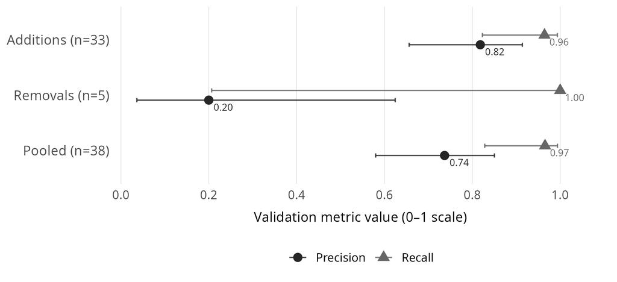

- High precision and recall for additions
- Most apparent removals were not confirmed; estimates remain uncertain (small sample)

## Limitations

DISCUSSION

- Historical GSV imagery is only a proxy for ground truth
- Validation had to be carried out manually
- Removal estimates remain uncertain
- Findings may not generalise to other cities

## Conclusions

DISCUSSION

**Can we trust OSM to measure cycling-infrastructure change?**

It depends on the type of change being measured

- Additions are detected reliably
  - Useful for tracking cycling-network expansion
- Removal estimates remain uncertain
  - Often reflect mapping edits rather than real infrastructure loss

OSM accuracy should not be assumed everywhere

- Performance may differ across cities

Main contribution

- Reproducible framework to measure, evaluate, and calibrate OSM-derived change where suitable validation data are available

### Thank you · 谢谢

### Questions?

eugeni.vidal@uab.cat

Code and reproducible workflow available upon request